# ESP106-Lab4

Kelsea MacDonald

January 29, 2023

```r
setwd("~/Library/CloudStorage/OneDrive-UniversityofCalifornia,Davis/ESP106/esp106-kelsea_macdonald/lab week 4")
```

## Lab 4

In this lab we will look at daily tidy data downloaded from NOAA’s Tides and Currents API (Application Programming Interface) for six cities around the US. I used the API to obtain six csv files containing data for tide gauges in each city. The tide gauges have numerical codes that correspond to the city as follows:

1. Boston: 8443970
2. New York: 8518750
3. Baltimore: 8574680
4. Charleston: 8665530
5. Miami: 8723214
6. Corpus Christi: 8775296

Before you start: add this file to your github repository, and commit your changes throughout the time you work on it.

### Part 1 - Monday

#### 1. Create a data frame containing data on the city name and tide gauge ID

```r
city <- c('Boston', 'New York', 'Baltimore', 'Charleston', 'Miami', 'Corpus Christi')
ID <- c(8443970, 8518750, 8574680, 8665530, 8723214, 8775296)
a <- data.frame(city, ID)
a
```

```
##             city      ID
## 1         Boston 8443970
## 2       New York 8518750
## 3      Baltimore 8574680
## 4     Charleston 8665530
## 5          Miami 8723214
## 6 Corpus Christi 8775296
```

#### 2a. Use a for-loop to read in the csv files and bind them together into a single data frame. Add a column to the data frame giving the name of the city the data is from.

```r
#Hint: you can use list.files() to get a vector of all the file names in a directory. Setting full.names=TRUE in the list.files() function will give you the full path name that can be used by read.csv
list.files(full.names=TRUE)
```

```
##  [1] "./8443970.csv"        "./8518750.csv"        "./8574680.csv"
##  [4] "./8665530.csv"        "./8723214.csv"        "./8775296.csv"
##  [7] "./ESP106_week4.html"  "./ESP106_week4.Rmd"   "./station8443970.csv"
## [10] "./station8518750.csv" "./station8574680.csv" "./station8665530.csv"
## [13] "./station8723214.csv" "./station8775296.csv"
```

```r
files <- list.files(pattern = '\\.csv') #first I create a name for all my csv's
#Hint 2: you might want to create a data frame using the first csv file. Then loop through from files 2 to 6 reading in the csv file and using rbind() to attach it to the bottom of your full data frame
b <- read.csv(files[1]) #then I read the first csv
b <- cbind(b,"city"=a[1,1], "ID"=a[1,2]) # bind the city and ID as new columns
 for(i in 2:6) {
   c <- read.csv(files[i])
   c <- cbind(c,"city"=a[i,1],"ID"=a[i,2]) # adding city and ID columns to each csv
   b <- rbind(b,c) # bind the new csv rows to the previous data.frame
 } # b now holds the combined data.frame

#Hint 3: It will be easiest to add the names of the city to the data frames immediately after reading them in, before binding everything together into a single data-frame
```

#### 2b. Take a look at your data frame - is this in a tidy format?

We are going to examine the question of whether these gauges show evidence of rising sea levels. One of the first things we have to deal with is the issue of dates.

Your data frame right now has one column with a year and one with the month. We are going to combine these into a single column, and use as.Date to formally use Date objects

#### 3a. Create a new column named “Date” that has the first day of the month for that row in the format YYYY-MM-01 where YYYY is the data in the Year column and MM is the data in the Month column.

```r
#Hint: Use paste0() to combine data and characters (i.e. the required separators"-")
d <- cbind(b, "Date"=paste0(b$Year,"-",b$Month,"-01"))
# d now contains the complete data.frame
```

#### 3b. Use as.Date to convert your new date column to a date object in R

```r
d$Date <- as.Date(d$Date)
```

Now lets use ggplot to make some cool graphs of this data using ggplot.

#### 4. Make a plot showing data from all 6 gauges on the same plot. Use different colors to distinguish lines for the different cities. See the example plot uploaded to Canvas (Plot 1)

- Plot the date on the x axis and MHHW (mean higher high water - i.e. the average daily high water level) on the y axis Make sure to add proper axis labes and units (using +labs(x=““,y=”“))
- Add a single best-fit line through the full data set using geom_smooth(method=“lm”) - note that by default ggplot will fit one best fit line for each city. To override this specify the aestetic mapping (aes()) again within the geom_smooth function and add the argument inherit.aes=FALSE

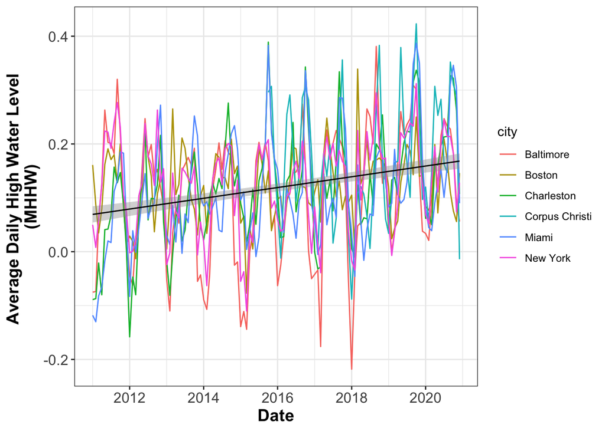

```r
#if you don't already have ggplot2 then install it with install.packages("ggplot2")
library(ggplot2)
d$ID <- as.character(d$ID)
th=theme_bw()+theme(strip.background =element_rect(fill="white"), axis.text=element_text(size=12),
        axis.title=element_text(size=14,face="bold")) # theme copied from lecture to make white background and then increased and bolded title sizes
ggplot(d, aes(Date, MHHW, colour = city)) + th + # setting x and y axes and assigning each city a color
  geom_line(aes(x=Date, y=MHHW)) + # this makes the plot a line graph
  geom_smooth(aes(x=Date, y=MHHW), method=lm, inherit.aes = FALSE, # this is the line of best fit
  col="black", size=.5) +
  labs(x="Date", y="Average Daily High Water Level \n(MHHW)")
```

#### 5. Now make a slightly different plot with the same x and y variables, but use facet_wrap() to make a subplot separately for each city. Add a best-fit line for each subplot. See the example plot uploaded to Canvas (Plot 2)

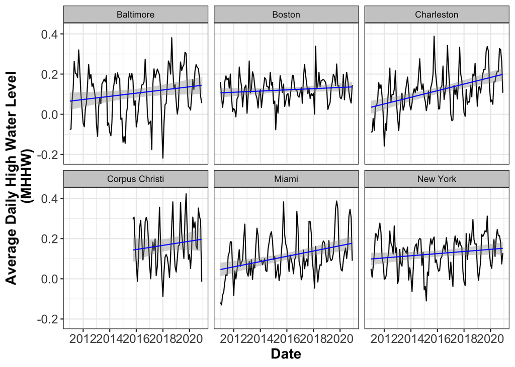

```r
#Hint: you should only need minor modification of the code from question 4 to make this plot
th=theme_bw()+theme(strip.background =element_rect(fill="grey80"), axis.text=element_text(size=12),
        axis.title=element_text(size=14,face="bold")) # repeated theme but made headers grey
ggplot(d, aes(Date, MHHW)) + th + # setting axes
  geom_line(aes(x=Date, y=MHHW)) + # line graph
  geom_smooth(aes(x=Date, y=MHHW), method=lm, inherit.aes = FALSE, # best fit line
  col="blue", size=.5) + # made it blue
  labs(x="Date", y="Average Daily High Water Level \n(MHHW)") +
  facet_wrap(~ city) # this divides the single plot into 6 different plots based on city
```

### Part 2 - Wednesday

In this part of the lab we will identify some outliers, and practice running regressions

#### 6. Make a box plot showing the distribution of the highest tides each month (“Highest” column in the NOAA data) . (Ideally practice using ggplot by using geom_boxplot() - put the city on the x axis and Highest on the y. But this can also be done in base R). See the example plot on Canvas (Plot 3)

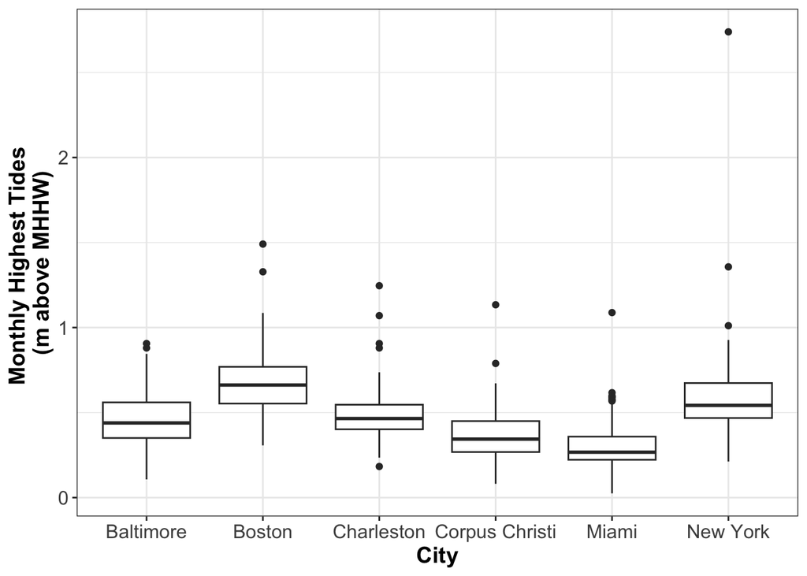

```r
th=theme_bw()+theme(strip.background =element_rect(fill="white"), axis.text=element_text(size=12),
        axis.title=element_text(size=14,face="bold"))
ggplot(d, aes(city, Highest)) + th +
  geom_boxplot(aes(x=city, y=Highest)) + # boxplot of MHHW based on city
  labs(x="City", y="Monthly Highest Tides \n(m above MHHW)")
```

Notice the very extreme value in New York City - a major outlier both within New York and compared to all the other cities

#### 7a. Find the row in the data corresponding to this outlier observation

```r
#Hint: The which.max() function might be useful here
which.max(d$Highest) # row 141 is the outlier
```

```
## [1] 141
```

#### 7b. What month and year did this outlier event occur in? What meteorological event happened in New York in that month that probably caused this outlier event? (Feel free to use Google - I don’t expect you to know this off hand)

**Date=2012-10-01, Hurricane Sandy hit NYC in October 2012**

Finally, we will fit a linear model to estimate the rate of sea-level rise across these 6 cities.

#### 8a. Fit a linear regression with the mean higher high water (MHHW) as the dependent variable and date (i.e. time) as the independent variable.

```r
#Hint: the forumla in your lm() function is of the form y~x where y here is MHHW and x is your date column
m <- lm(MHHW~Date,data=d)
summary(m)
```

```
##
## Call:
## lm(formula = MHHW ~ Date, data = d)
##
## Residuals:
##      Min       1Q   Median       3Q      Max
## -0.35710 -0.06419  0.00207  0.06161  0.27239
##
## Coefficients:
##               Estimate Std. Error t value Pr(>|t|)
## (Intercept) -3.399e-01  6.002e-02  -5.663 2.23e-08 ***
## Date         2.732e-05  3.552e-06   7.692 5.31e-14 ***
## ---
## Signif. codes:  0 '***' 0.001 '**' 0.01 '*' 0.05 '.' 0.1 ' ' 1
##
## Residual standard error: 0.09572 on 656 degrees of freedom
## Multiple R-squared:  0.08274,    Adjusted R-squared:  0.08134
## F-statistic: 59.17 on 1 and 656 DF,  p-value: 5.314e-14
```

#### 8b. Give the estimated coefficient of the date column. Is it statistically significant (i.e. has a p-value less than 0.05)?

**The estimated coefficient of the date column is 2.732e-05 and it is statistically significant**

This coefficient gives us the average increase in high tide levels each day, across all six cities, for this ten year time frame (i.e. the units of the coefficient are in m per day).

#### 8c. Using your estimated coefficient, estimate the mean increase in sea-level over the 10 year time frame from 2011-2020.

```r
# est. coefficient of date column is 2.732e-05, meaning an increase of 2.732e-05 meters per day
# to get the mean increase in sea-level over 1 year, we need to multiply by 365
# finally to show the mean increase over the 10 year period we multiply by 10
peryear=2.732e-05*365
per10=peryear*10 # I inserted this code directly into the text below for my answer.
```

**The mean increase in sea-level over the 10 year time frame is 0.099718 meters.**

Upload your .Rmd file and you knitted file with the answers and plots to Canvas

##STRETCH GOAL

If you are looking for a challenge, have a go downloading the original csv files directly from the NOAA API. Details on the API are here: https://api.tidesandcurrents.noaa.gov/api/prod/

You will want to paste together a URL describing the data you want from the API, then use download.file() to download the data from that URL into a directory on your computer.

The URL you want will have the following form, except you will loop through to replace *GAUGEID* with each of the six tide gauge ID numbers:

paste0(“https://api.tidesandcurrents.noaa.gov/api/prod/datagetter?begin_date=20110101&end_date=20201231&station=”,*GAUGEID*,“&product=monthly_mean&datum=MHHW&units=metric&time_zone=lst&format=csv”)

See if you can make sense of this URL given the options listed at the website describing access to the API

```r
for(i in 1:6) {
  p <- (paste0("https://api.tidesandcurrents.noaa.gov/api/prod/datagetter?begin_date=20110101&end_date=20201231&station=", ID[i], "&product=monthly_mean&datum=MHHW&units=metric&time_zone=lst&format=csv"))
  download.file(p, basename(p)) # successfully downloaded to my lab 4 folder
  file.rename(from=basename(p),to=paste0("station", ID[i], ".csv")) # renamed file to something simpler
}
# the url reads as... data from jan 1 2011 to dec 31 2020, the station number was plugged in using a for loop, the product was verified monthly mean water level data for the station, the datum downloaded was MHHW, it is given in metric units, the time zone is local, and the format is a csv file
```